# CS107 Final Froject : Sentiment Analysis of Product Reviews

Sahbi Ben Gdaiem, Mohammed Hadj-Ali

April 27, 2016

# 1 Introduction

## 1.1 Motivation :

Sentiment Analysis, is receiving a big attention these days, because of its huge specrum of applications ranging from product review analysis, compain feedback, competition benchmarking, customer profiles, political trends, etc…

There is a huge flow of information coming from the internet and social networks. Online discussions are only relevant to people for a couple of days. Nobody actulaly goes in past tweets for more than a week, for instance. This entire humanity archive of discussion could help in many applications if we train machines to understand the sentiment of people towards a specific theme at a specific time.

## 1.2 Background

“Sentiment analysis is the computational study of people’s opinions, sentiments, emotions, and attitudes.” [Excerpt From: Bing Liu. Sentiment Analysis: Mining Opinions, Sentiments, and Emotions.]

Given the large amount of data available on the Web, it is now possible to investigate high-level Information Retrieval tasks like user’s intentions and feelings about facts or objects discussed. [Pang, B., Lee, L., 2008. Opinion mining and sentiment analysis. Foundations and Trends in Information Retrieval]

# 2 Sentiment Analyis

## 2.1 Challenge :

There are several things to take into consideration when approaching a Sentiment Analysis task. In general, there are two main approaches:

- Sentiment lexicons using Natural Language Processing (NLP) techniques. A Sentiment lexicon is a list of words that are associated to polarity values (positive or negative). NLP techniques offer a deep level of analysis since they take into account the context words in the sentence.
- Machine Learning classification algorithms. Because sentiment classification is a text classification problem, any existing supervised learning method can be directly applied [Bing Liu]. For example, naïve Bayes classification , logistic regression, support vector machines (SVM), etc..

```
##     jsonlite           tm      stringr        knitr      ggplot2
##         TRUE         TRUE         TRUE         TRUE         TRUE
##        dplyr randomForest        caret        e1071         MASS
##         TRUE         TRUE         TRUE         TRUE         TRUE
##    wordcloud        tidyr     tidytext         pROC
##         TRUE         TRUE         TRUE         TRUE
```

## 2.2 Data Wrangling and Preparation

### 2.2.1 Load data

In this work we’ll use a dataset that we obtained thankfully from Julian McAuley, at University of San Diego here http://jmcauley.ucsd.edu/data/amazon/

We’ll use their SIGIR and KDD papers (listed on the above page) as a baseline for our accuracy benchmarking.

This dataset contains product reviews and metadata from Amazon, including 142.8 million reviews spanning May 1996 - July 2014. We’ll be using electronics reviews for this work.

```r
# TODO: Set working directory to where this script is (avoid hardcoded paths)
this.dir <- "/Users/sahbi/HES/CS107/final project/cs107final/"
setwd(this.dir)

#json_file <- "data/reviews_electronics_extract.json"
json_file <- "data/reviews_electronics_extract.json.gz"
```

The file format is **NDJSON** (Newline Delimited JSON), So `stream_in` is the approriate way of to load the data into a data frame.

```r
dat <- stream_in(gzfile(json_file), verbose = FALSE)
dat <- dat %>% head(100)    ## comment after testing

#Preview the result.
glimpse(dat)
```

```
## Observations: 100
## Variables: 9
## $ reviewerID     (chr) "AKM1MP6P0OYPR", "A2CX7LUOHB2NDG", "A2NWSAGRHCP...
## $ asin           (chr) "0132793040", "0321732944", "0439886341", "0439...
## $ reviewerName   (chr) "Vicki Gibson \"momo4\"", "Bernie", "bowmans200...
## $ helpful        (list) 1, 1, 0, 0, 1, 1, 1, 1, 4, 4, 0, 0, 1, 1, 0, 1...
## $ reviewText     (chr) "Corey Barker does a great job of explaining Bl...
## $ overall        (dbl) 5, 5, 1, 3, 1, 5, 2, 5, 5, 5, 5, 5, 1, 5, 1, 4,...
## $ summary        (chr) "Very thorough", "Adobe Photoshop CS5 Crash Cou...
## $ unixReviewTime (int) 1365811200, 1341100800, 1367193600, 1374451200,...
## $ reviewTime     (chr) "04 13, 2013", "07 1, 2012", "04 29, 2013", "07...
```

## 2.3 Exploratory Data Analysis

### 2.3.1 Basic numbers

Let’s explore some facts about our data.

```r
n_distinct(dat$reviewerID)
```

```
## [1] 100
```

Checking how many products are there using the distinct ASIN (Amazon Standard Identification Number) amazon’s unique product idenntifier.

```r
n_distinct(dat$asin)
```

```
## [1] 20
```

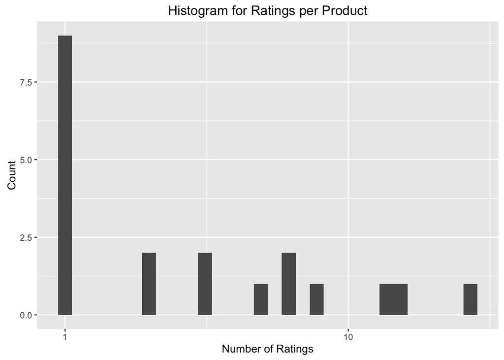

```r
dat %>% group_by(asin) %>%
        summarize(n_ratings = n() ) %>%
        ggplot(aes(n_ratings)) +
        geom_histogram() +
        scale_x_log10() +
        labs(title="Histogram for Ratings per Product") +
        labs(x="Number of Ratings", y="Count")
```

```r
# best seller
dat %>% group_by(asin) %>%
        summarize(n_ratings = n() ) %>% arrange(desc(n_ratings)) %>% head(1) %>% .$asin
```

```
## [1] "0528881469"
```

### 2.3.2 Simplification of data

```r
df <- dat %>% mutate(reviewText = reviewText) %>%
              dplyr::select(reviewText, overall)
# rm(dat)  ## TODO : uncomment for production version
gc()
```

```
##           used (Mb) gc trigger  (Mb) max used  (Mb)
## Ncells 1729175 92.4    2637877 140.9  2164898 115.7
## Vcells 2206127 16.9    3851194  29.4  3142660  24.0
```

### 2.3.3 Rating system in Amazon

The rating system used in Amazon is as follows :

- emotional positive (5 stars)
- rational positive (4 stars)
- neutral (3 stars)
- rational negative (2 stars)
- emotional negative (1 star )

**The user’s star rating of his own review description as a subjective human interpretation of opinion. So, we consider that as the ground truth.**

Let’s see the distribution of these ratings in our case

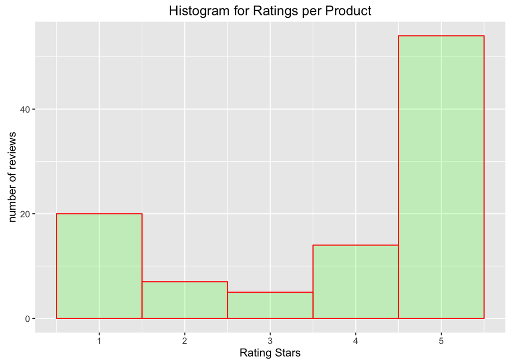

```r
df %>%  ggplot(aes(overall)) +
geom_histogram(binwidth=1,
               col="red",
               fill="green",
               alpha = .2) +
                labs(title="Histogram for Ratings per Product") +
                labs(x="Rating Stars", y="number of reviews")
```

```r
mean(dat$overall)
```

```
## [1] 3.75
```

> The ratings are very skewed towards positive feedback. Which is an indication that Amazon is not selling junk at least but it’s not going to help in our modeling. We have to have equal likelihood of each class of the ratings.

> In the next sections we’ll solve this.

## 2.4 Design decisions on reviews

In this work we will have a binary classification. Either Positive or Negative. We objectively chose to demarcate each rating at the 2.x level divide, such that star ratings above this level would be marked as “1” and star ratings below this level would be marked as “0”

So at the end we’ll have only 2 opinions : negative/positive The simplest way to do this is by joining a mapping matrix

```r
overall <-seq(1,5)
rating <- c(0,0,1,1,1)
trans <- data.frame(cbind(overall, rating))

df <- df %>%
      filter(overall != 3)  %>%
      inner_join(trans) %>%
      dplyr::select(-overall) %>%
      mutate(id = row_number())
```

Let’s check again the distribution of opinions

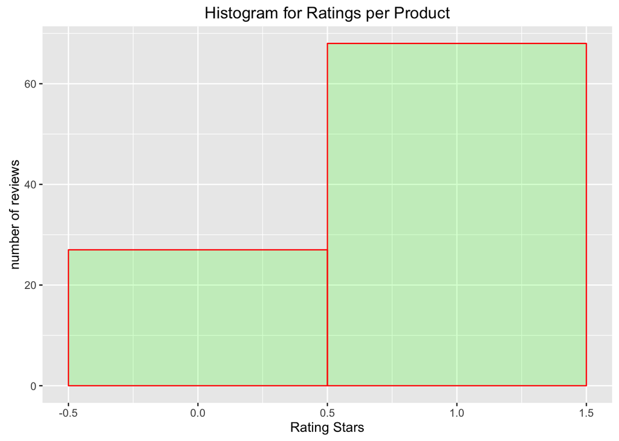

```r
df %>%  ggplot(aes(rating)) +
        geom_histogram(binwidth=1,
               col="red",
               fill="green",
               alpha = .2) +
labs(title="Histogram for Ratings per Product") +
labs(x="Rating Stars", y="number of reviews")
```

Even after this mapping the class proportions need to be corrected manually. We calculate the skew (disproportion rate)

```r
sum(df$rating == 0) / sum(df$rating == 1)
```

```
## [1] 0.3970588
```

```r
n_remov <- sum(df$rating == 1) - sum(df$rating == 0)
```

```r
positive_ids <- df$id[df$rating == 1]
remove_ids <-  sample(positive_ids, n_remov)

## remove these rows
df3 <- df[-remove_ids,]
```

Check the numbers, we are good to go :

```r
sum(df3$rating == 0) / sum(df3$rating == 1)
```

```
## [1] 1
```

```r
## clean up things
df <- df3
rm(df3, dat, positive_ids, remove_ids)
gc()
```

```
##           used (Mb) gc trigger  (Mb) max used  (Mb)
## Ncells 1729802 92.4    2637877 140.9  2637877 140.9
## Vcells 2205493 16.9    3851194  29.4  3142660  24.0
```

## 2.5 Machine Learning

### 2.5.1 Bag of Words

One of the simpler things to do with text is to treat each text as a “bag of words”. We have used the `tm` package in order to construct a Term Document Matrix but the computer couldn’t handle such huge dimensions. So let’s go with `tidytext`

### 2.5.2 Text tidiying

Do a serie of transformations :

- lowecase
- remove punctutations
- strip whitespace

```r
df$reviewText <- gsub( "[^a-zA-Z]", "\\1 \\2", tolower(df$reviewText))
df$reviewText <- gsub( " +", " ", df$reviewText)
```

Use `nrc` lexicon as a bag of words that have sentiments but we’re not going to look into these sentiments for the time being.

```r
bow <- sentiments %>%
    filter(lexicon == "nrc") %>%
    dplyr::select(word)
```

### 2.5.3 Creating features from Bag of Words

Use `unrest_tokens` and join function in order to convert our reviews into a sparse Matrix.

```r
Xdf <- df %>%
    unnest_tokens(word, reviewText) %>%
    filter(!word %in% stop_words$word) %>%
    inner_join(bow) %>%
    count(word, id) %>%
    spread(word, n, fill = 0) %>%
    dplyr::select(-id)
# we transpose id because we want docunent as
Xmat <- as.matrix(Xdf)
dim(Xmat)
```

```
## [1]  48 171
```

### 2.5.4 Reduce dimensionality (Simgle Vector Decomposition)

Suppose we have m words (features) and n documents Single vector decomposition (SVD) of an m*n real or complex matrix X is a factorization of the form :

$$X = U \Sigma V^{T}$$
$$U\ is\ m x r\ matrix,\ columns\ of\ U\ contain\ the\ Eigenvectors\ of\ X \cdot X^{T}$$
$$V\ is\ an\ r x n,\ columns\ of\ V\ contain\ the\ Eigenvectors\ of\ X^{T} \cdot X$$
$$\Sigma\ is\ a\ diagonal\ r x r\ matrix.\ diagonal\ values\ are\ eigenvalues\ of\ X \cdot X^{T}$$

It’s basically a PCA but without mean shifting.

```r
Xmat.svd <- svd(Xmat, nu=30, LINPACK=T)
save(Xmat.svd, file=paste(this.dir, "Xmat.svd", ".RData", sep=""))
#load(paste(this.dir, 'Xmat.svd', '.RData', sep=''))

dim(Xmat.svd$u)
```

```
## [1] 48 30
```

```r
length(Xmat.svd$d)
```

```
## [1] 48
```

```r
dim(Xmat.svd$v)
```

```
## [1] 171  48
```

The diagonal vector d generated is ordered by importance of each dimension. Let’s graph a cumulative variance

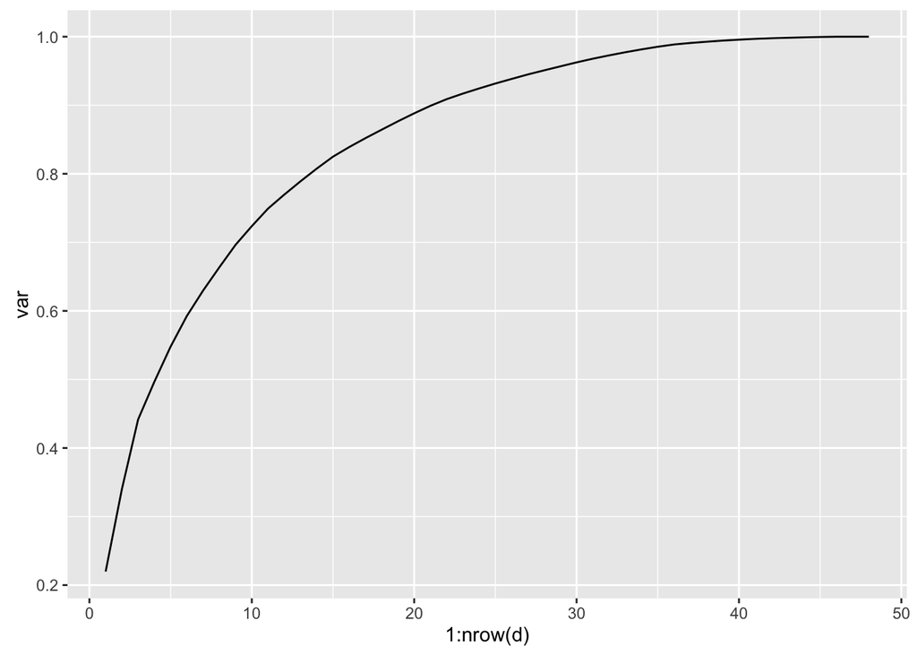

```r
#Xmat.svd$d
s <- sum(Xmat.svd$d)
d <- data.frame(var = cumsum(Xmat.svd$d^2/sum(Xmat.svd$d^2)))
ggplot(d, aes(x=1:nrow(d), y=var)) + geom_line() #+ scale_x_log10()
```

```r
#round(Xmat.svd$u %*% diag(Xmat.svd$d) %*% t(Xmat.svd$v))

pc.use <- 30
recon <- Xmat.svd$u[,1:pc.use] %*% diag(Xmat.svd$d[1:pc.use]) %*% t(Xmat.svd$v[,1:pc.use])
```